# Batch effect on Pleurotus LC-MS/MS samples

Author

Romanos Siaperas

Published

January 28, 2025

# 1 Introduction

This is an analysis to investigate the effect of different experimental and LC-MS/MS batches on the analysis. The two experiment batches include liquid cultures, protein extraction and freeze-drying and were performed by two different persons in the Biotechnology Laboratory (NTUA, Greece). The two different MS batches have differences in both peptide purification and LC-MS/MS. **No batch correction was performed**.

## 1.1 Experimental design

The MS depends on the different batches analyzed by VIB. There are 3 different projects but PRC-5442 and PRC-5590 have identical sample preparation (PRC-5590 had just some extra cleaning steps) and MS section and were analyzed in 2021-08 and 2022-01 respectively so will be set in the same MS batch. PRC-6063 was analyzed in 2023-06.

| Sample | Batch | Experiment | VIB project | Filename |
| --- | --- | --- | --- | --- |
| bw_1 | exp2_ms2 | Rom | 6063 | B28553_10ul_IonOpt_PRC6063 |
| bw_2 | exp2_ms2 | Rom | 6063 | B28543_10ul_IonOpt_PRC6063 |
| bw_3 | exp2_ms2 | Rom | 6063 | B28545_10ul_IonOpt_PRC6063 |
| cs_1 | exp1_ms1 | Maria | 5590 | E28115_5ul_PAC_PRC5590 |
| cs_2 | exp1_ms2 | Maria | 6063 | B28547_10ul_IonOpt_PRC6063 |
| cs_3 | exp1_ms2 | Maria | 6063 | B28549_10ul_IonOpt_PRC6063 |
| xyl_1 | exp1_ms1 | Maria | 5442 | E26698_3ul_PAC_PRC5442 |
| xyl_2 | exp1_ms1 | Maria | 5442 | E26704_3ul_PAC_PRC5442 |
| xyl_3 | exp2_ms2 | Rom | 6063 | B28551_10ul_IonOpt_PRC6063 |

## 1.2 Differences in LC-MS/MS analysis

### 1.2.1 Sample preparation

Very similar steps.

- Proteins dissolved in 5% SDS in 50 mM TEAB. In ms1 to a final concentration of 1 μg/μl, to ms2 not mentioned.
- Reduction, alkylation, protein binding in S-Trap columns and elution identical.
- PRC-5590 sample and ms2 samples were subjected ton an additional purification step on Omix C18 tips.

### 1.2.2 LC-MS/MS

- **Peptide Load**: 3 μl for ms1, 10 μl for ms2
- **LC**: Trapping and separation were performed in columns with different diameter and with different gradient (155 min for ms1, 165 min for ms2)
- **Mass spectrometer**: Q Exactive Orbitrap for ms1, Q Exactive HF Orbitrap for ms2
- **MS1**: Top 5 and 12 most abundant peaks with maximum ion injection time 80 and 120 ms, 70,000 and 60,000 resolution respectively
- **MS2**: Collision energy 25% and 28%, resolution 17,500 and 15,000, isolation windows 2 Da and 1.5 m/z (m is the ion mass in Da)

## 1.3 Batch correction

Some notes about batch correction and proteomics.

1. Batch correction is performed after normalization and is suggested at the peptide before protein aggregation (10.15252/msb.202110240). You apply the correction at the level your signal is.
2. Only appropriate method for batch correction of intensity data like proteomics and microarrays is ComBat. ComBat needs imputation, does not accept missing values in a given batch. We artificially change the majority of our data since we have many missing values in DDA LFQ.
3. Batch corrected data can not be tested for differential abundance analysis.
   - Quoting Li et al. (10.1093/biostatistics/kxab039):

     Batch correction introduces a correlation structure in the corrected data, which, if ignored, may lead to either exaggerated or diminished significance in downstream applications such as differential expression analysis. In a typical batch adjustment, the batch mean and/or variance are estimated using all the data points in the particular batch, and then this estimated batch mean is subtracted from each data point in the batch. This means that the adjusted data points within each batch are correlated with each other and that leads to exaggerated significance in the tests of differential expression.
   - Quoting Nygaard et al. (10.1093/biostatistics/kxv027):

     Some tools therefore have the option of preserving the difference between study groups, e.g. using a two-way ANOVA model to simultaneously estimate both group and batch effects. Unfortunately, this approach may systematically induce incorrect group differences in downstream analyses when groups are distributed between the batches in an unbalanced manner.
   - See also discussion in Biostars https://www.biostars.org/p/266507/#280157
4. Will proceed with standard quantitative analysis and will include the batches at the lm model as covariates when testing differential expression following Gordon Smyth’s comment https://support.bioconductor.org/p/36029/#100297 .

# 2 Analysis

## 2.1 Libraries and functions

```r
library(dplyr)
library(tidyr)
library(ggplot2)

library(limma)
library(prolfqua)

library(SummarizedExperiment)
library(BatchQC)
library(imputeLCMD)
library(PCAtools)

library(RscriptsForProteomics)
```

```r
# Imputes the peptide dataframe with the given method, creates a summarized experiment and assigns the 3 different batch types
impute_se <- function(data, impute_method) {

  if (impute_method == "MinProb") {
        data <- impute.MinProb(data)
  }
  if (impute_method == "MinDet") {
        data <- impute.MinDet(data)
  }

  se_object <- BatchQC::summarized_experiment(data, batches)
  SummarizedExperiment::assayNames(se_object) <- "log_intensity"

  se_object <- BatchQC::batch_correct(se = se_object, method = "ComBat", assay_to_normalize = "log_intensity", batch = "comb_batch",
                                    covar = c("condition"), output_assay_name = "Combat_comb")
  se_object <- BatchQC::batch_correct(se = se_object, method = "ComBat", assay_to_normalize = "log_intensity", batch = "ms_batch",
                                    covar = c("condition"), output_assay_name = "Combat_ms")
  se_object <- BatchQC::batch_correct(se = se_object, method = "ComBat", assay_to_normalize = "log_intensity", batch = "exp_batch",
                                    covar = c("condition"), output_assay_name = "Combat_exp")

  return(se_object)
}



plot_variation <- function(se_object) {
  p1 <- BatchQC::EV_plotter(batchqc_ev = batchqc_explained_variation(se = se_object,batch = "comb_batch",
                                                                   condition = "condition", assay_name = "log_intensity")[[1]]) +  labs(title = "Combined batch uncorrected")
p3 <- BatchQC::EV_plotter(batchqc_ev = batchqc_explained_variation(se = se_object,batch = "ms_batch",
                                                                   condition = "condition", assay_name = "log_intensity")[[1]])  + labs(title = "MS batch uncorrected")
p5 <- BatchQC::EV_plotter(batchqc_ev = batchqc_explained_variation(se = se_object,batch = "exp_batch",
                                                                   condition = "condition", assay_name = "log_intensity")[[1]]) +   labs(title = "Experiment batch uncorrected")
p2 <- BatchQC::EV_plotter(batchqc_ev = batchqc_explained_variation(se = se_object,batch = "comb_batch",
                                                                   condition = "condition", assay_name = "Combat_comb")[[1]]) +  labs(title = "Combined batch corrected")
p4 <- BatchQC::EV_plotter(batchqc_ev = batchqc_explained_variation(se = se_object,batch = "ms_batch",
                                                                   condition = "condition", assay_name = "Combat_ms")[[1]])  + labs(title = "MS batch corrected")
p6 <- BatchQC::EV_plotter(batchqc_ev = batchqc_explained_variation(se = se_object,batch = "exp_batch",
                                                                   condition = "condition", assay_name = "Combat_exp")[[1]]) +   labs(title = "Experiment batch corrected")

 gridExtra::grid.arrange(p1, p2, p3, p4, p5, p6)
}
```

## 2.2 Load in prolfqua

Read the SDRF and parse save the sample-batches relationship in a dataframe for later use.

```r
# read sdrf
sdrf <- read.delim("data/MS/sdrf.tsv")
sdrf <- sdrf %>%
  mutate(project = gsub(".*PRC([0-9]*)\\.raw", "\\1", comment.data.file.),
         ms_batch = if_else(project == "6063", 2, 1),
         exp_batch = if_else(factor.value.substrate. == "beechwood", 2, 1),
         exp_batch = if_else(factor.value.substrate. == "xylose" & project == "6063", 2, exp_batch)
  )

# create the sample-batches dataframe
batches <- data.frame(row.names = gsub( "\\.raw", "", sdrf$comment.data.file.) )
batches$ms_batch <- as.factor(sdrf$ms_batch)
batches$exp_batch <- as.factor(sdrf$exp_batch)
batches$condition  <- as.factor(gsub(" ", "", sdrf$factor.value.substrate.))
batches$comb_batch <-  as.factor(paste0("e", batches$exp_batch, "_m", batches$ms_batch))
batches
```

```
                           ms_batch exp_batch   condition comb_batch
E26698_3ul_PAC_PRC5442            1         1      xylose      e1_m1
E26704_3ul_PAC_PRC5442            1         1      xylose      e1_m1
B28551_10ul_IonOpt_PRC6063        2         2      xylose      e2_m2
E28115_5ul_PAC_PRC5590            1         1 corn_stover      e1_m1
B28547_10ul_IonOpt_PRC6063        2         1 corn_stover      e1_m2
B28549_10ul_IonOpt_PRC6063        2         1 corn_stover      e1_m2
B28553_10ul_IonOpt_PRC6063        2         2   beechwood      e2_m2
B28543_10ul_IonOpt_PRC6063        2         2   beechwood      e2_m2
B28545_10ul_IonOpt_PRC6063        2         2   beechwood      e2_m2
```

Now load in prolfqua. The PRC-6063 samples have a lower intensity, this will be treated in the robscaled normalization.

```r
data <- read.csv("data/MS/sdrf_openms_design_msstats_in.csv.gz")
lfqdata <- create_lfqdata(data)
knitr::kable(lfqdata$hierarchy_counts(), caption = "number of proteins and peptides.")
```

number of proteins and peptides.

| isotopeLabel | protein_Id | peptide_Id |
| --- | --- | --- |
| light | 2181 | 20990 |

Figure 1: Density of raw peptide intensities

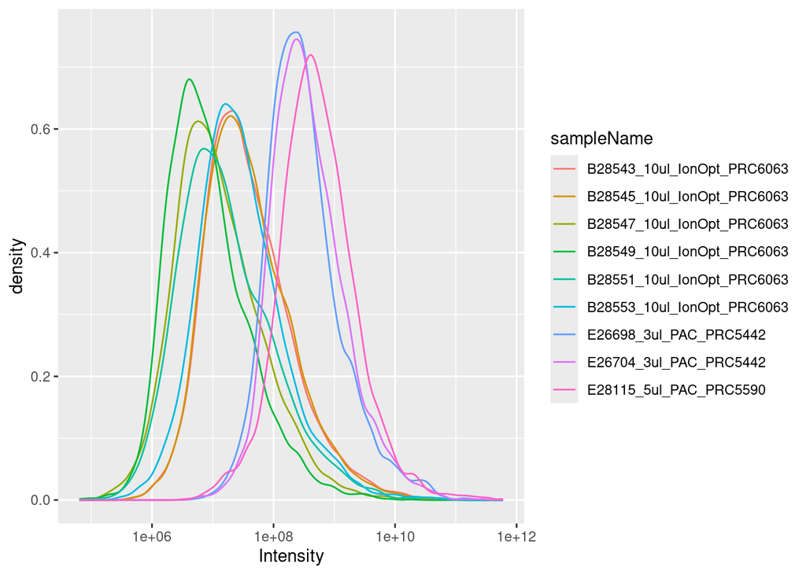

Figure 2: Density of raw peptide intensities

```r
# raw density plot
lfqdata$get_Plotter()$intensity_distribution_density()
```

This is the PCA of the robscaled peptide intensities. However PCA discards all peptides with missing values using only 1.7% of them.

```
[1] "348 peptides are quantified in all 9 samples and used for PCA (1.7%)"
```

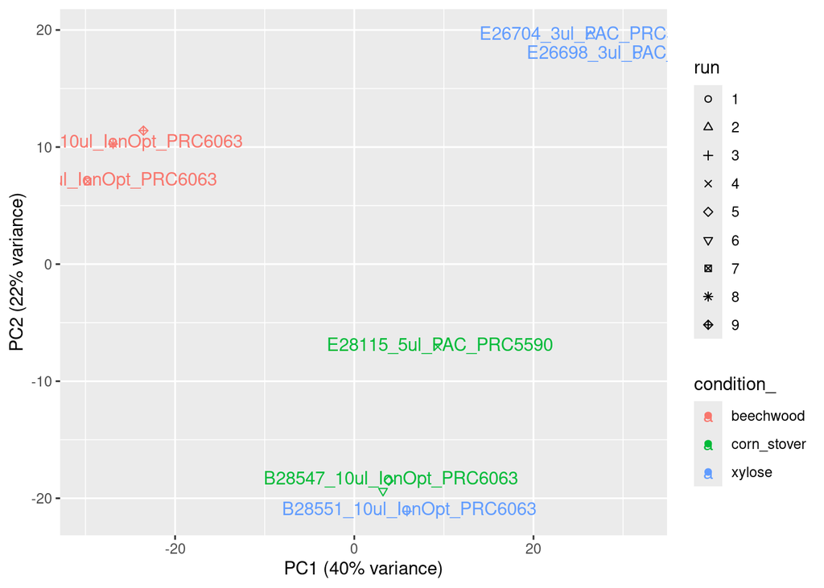

Figure 3: PCA of robscaled peptide intensities

```r
lt <- lfqdata$get_Transformer()
lfqdataPeptideNorm <- lt$log2()$robscale()$lfq

lfqdataPeptideNorm$get_Plotter()$pca()


pep_data <- data.frame(lfqdataPeptideNorm$to_wide()$data)

pep_df <- data.frame(lfqdataPeptideNorm$to_wide()$data)[,c(4:12)]
rownames(pep_df) <- data.frame(lfqdataPeptideNorm$to_wide()$data)$peptide_Id

paste0(na.omit(pep_df) %>% nrow()," peptides are quantified in all 9 samples and used for PCA (", round(na.omit(pep_df) %>% nrow() / pep_df %>% nrow() * 100, 1), "%)" )
```

## 2.3 Confounding of batches and substrate

The confounding of the different batches with the biological condition is the following. Experimental batches have the highest confounding since only xylose has replicates performed in separate experiments.

```r
se_object <- BatchQC::summarized_experiment(pep_df, batches)
SummarizedExperiment::assayNames(se_object) <- "log_intensity"
BatchQC::confound_metrics(se = se_object, batch = "condition")
```

```
           Pearson Correlation Coefficient Cramer's V
ms_batch                         0.7071068  0.5773503
exp_batch                        0.9074852  0.8366600
comb_batch                       0.8776504  0.7264832
```

## 2.4 Imputation of missing values

### 2.4.1 Without filtering

There are a lot of missing values of course but ComBat can not handle them so will impute with 2 different methods. MinDet which replaces missing values with the minimum value of the sample and MinProb which generates a (normal?) distribution around the minimum value.

First threw peptides present in less than 2 samples. This will affect samples with many missing values and completely change their distribution, let’s see number of NaN values in each sample

```
There are 20990 peptides in total.
Let's count NaN in each sample
```

```
B28543_10ul_IonOpt_PRC6063 B28545_10ul_IonOpt_PRC6063
                     10366                      10498
B28547_10ul_IonOpt_PRC6063 B28549_10ul_IonOpt_PRC6063
                     17166                      16484
B28551_10ul_IonOpt_PRC6063 B28553_10ul_IonOpt_PRC6063
                     18144                      13462
    E26698_3ul_PAC_PRC5442     E26704_3ul_PAC_PRC5442
                     14388                      13164
    E28115_5ul_PAC_PRC5590
                     15664
```

[output not shown]

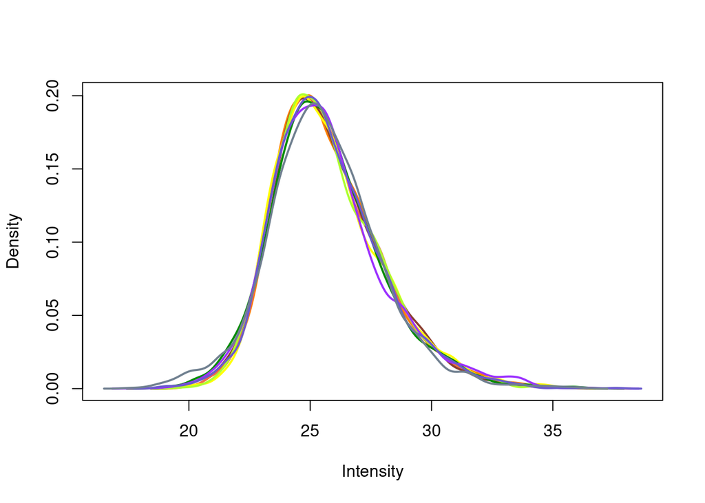

Figure 4: No imputation

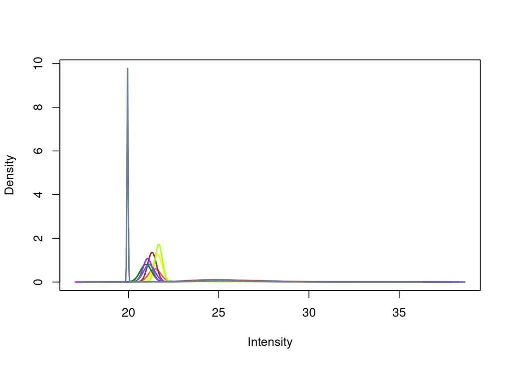

Figure 5: MinDet imputation

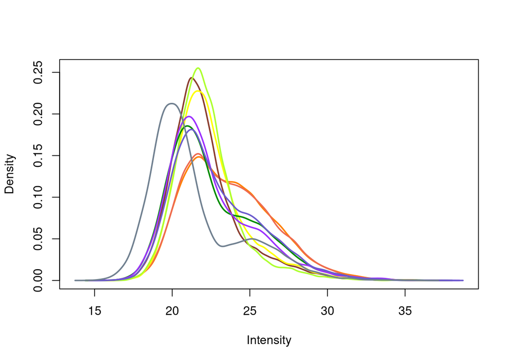

Figure 6: MinProb imputation

```r
cat("There are", nrow(pep_df), "peptides in total.\nLet's count NaN in each sample")
colSums(is.na(pep_df))
cols =   c("darkorange1", "coral2", "coral4", "yellow", "greenyellow", "green4", "purple1", "slateblue", "slategrey")
limma::plotDensities(pep_df, col =cols, legend = FALSE)
limma::plotDensities(impute.MinDet(pep_df), col = cols, legend = FALSE)
limma::plotDensities(impute.MinProb(pep_df), col = cols, legend = FALSE)
```

Corn stover sampels and xylose_3 have very few peptides and imputation shifts them a lot to the left.

### 2.4.2 With filtering

```r
# Allow only 4 missing values per peptide
pep_df <- pep_df[rowSums(is.na(pep_df)) <= 5, ]

se_object_md <- impute_se(pep_df, "MinDet")
se_object_mp <- impute_se(pep_df, "MinProb")
```

## 2.5 BatchQC

These plots are interesting but remember that more than 50% of the peptide intensities are imputed.

- The experimental and MS batch separate explain less variance than the biological condition.
- The experimental batch explains slightly more variance than the MS-sampling batch. Remember that this batch is more confounded with the biological condition.
- The combination of them explains more, similar to the biological conditions.

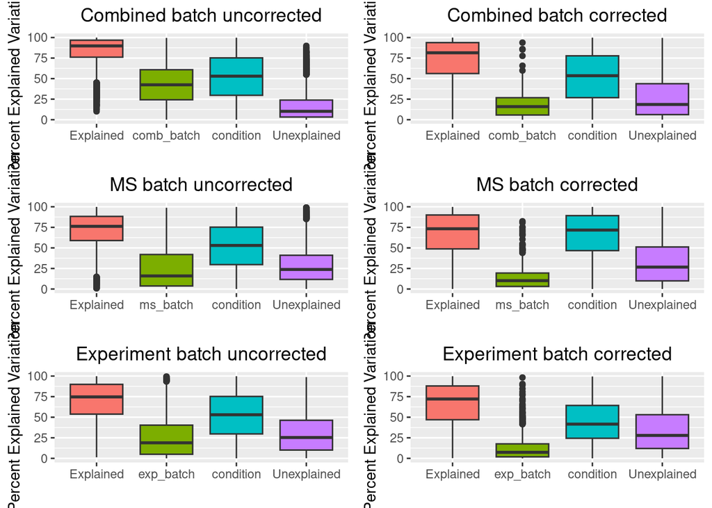

Figure 7: MinDet

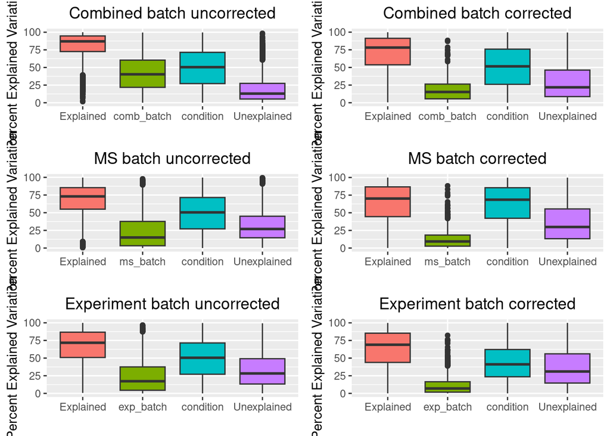

Figure 8: MinProb

As expected strong correlation of the bw samples. MinDet method has stronger correlation since all MVs are replaced with a single value. The e1_m1 samples cluster together but the cs_1 is quite distinct.

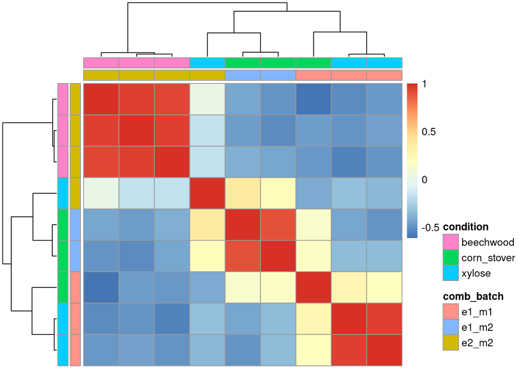

Figure 9: Heatmap correlation after MinDet

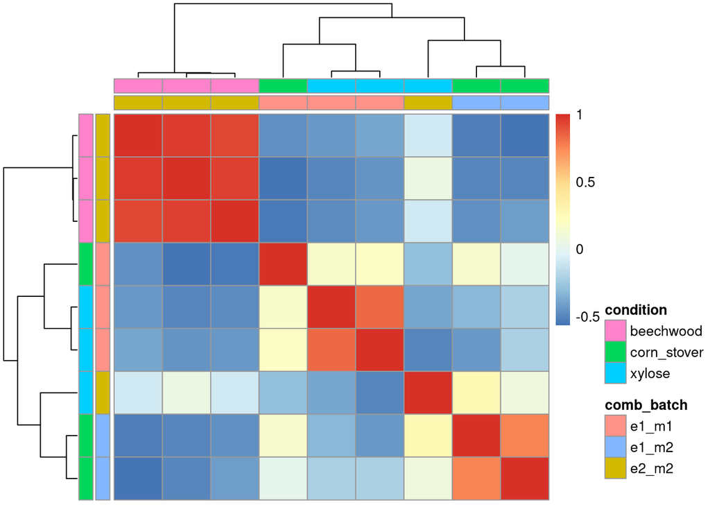

Figure 10: Heatmap correlation after MinProb

## 2.6 Protein aggregation

Let’s plot the PCAs of the robscaled peptide intensities and the Tukey’s median polish summarized protein intensities.

```r
# protein aggregation
mp_df <- protein_aggregation(lfqdataPeptideNorm)
# PCAtools wants the columns in the same order as the metadata rownames for some reason
mp_df_reordered <- mp_df[, c(2:10)][, match(rownames(batches), colnames(mp_df[, c(2:10)]))]

p <- PCAtools::pca(na.omit(mp_df_reordered), metadata = batches, removeVar = 0.1)
pca_plot <- PCAtools::biplot(p, colby = "condition", shape = 'comb_batch',
                 labSize = 5, pointSize = 5, legendPosition = "right")

horn <- parallelPCA(na.omit(mp_df_reordered))
elbow <- findElbowPoint(p$variance)
scree_plot <- PCAtools::screeplot(p,
                    components = getComponents(p, 1:20),
                    vline = c(horn$n, elbow)) +

  geom_label(aes(x = horn$n + 0.5, y = 50,
                 label = 'Horn\'s', vjust = -1, size = 8)) +
  geom_label(aes(x = elbow + 1, y = 30,
                 label = 'Elbow method', vjust = -1, size = 8))
```

We see that protein aggregation groups replicates just fine without extra batch correction.

```
[1] "182 proteins are quantified in all 9 samples and used for PCA (8.3%)"
```

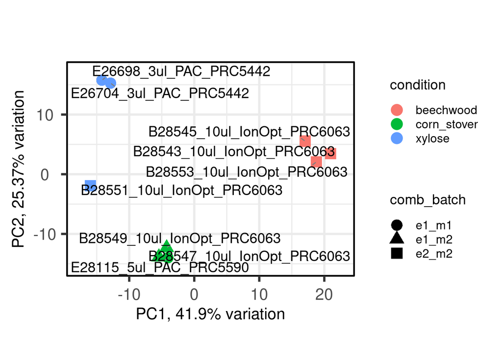

Figure 11: PCA of protein intensities

But again there are just 182 proteins present in all 9 samples, is PCA representative? Naah, and it seems two principal components are not enough as we see here.

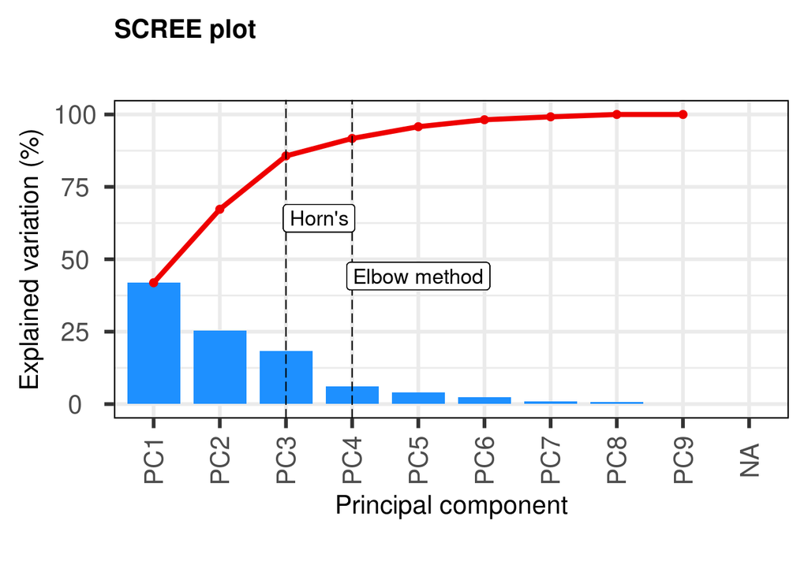

Figure 12: How many PCs explain the variance?

## 2.7 Sumary

No batch correction, daa. Will add the batches as covariates in the linear model when testing for differential abundance.